# Memorandum

```r
library(tidyverse)
library(tidycensus)
library(socviz)
library(lubridate)
library(sf)
library(scales)
library(arcpullr)
library(zoo)
library(grid)
library(viridis)
library(gridExtra)
library(gridtext)
library(ggtext)
library(dplyr)

options(scipen =999)
```

*Homework assignment for MUSA 6951 at the University of Pennsylvania - not an actual memo*

**TO:** James Garrow, Communications Director, Department of Public Health

**FROM:** Dave Drennan, Analyst, Department of Public Health

**DATE:** 28 November 2023

**SUBJECT:** Entering a heightened COVID risk period - let’s strengthen our communications and data collections strategies

**Introduction**  
We are no longer in an officially declared global pandemic, but COVID-19 remains a threat to the health and wellness of Philadelphia’s population. However, current communications from the city do not emphasize the risks that citizens may face this coming winter as we enter the holiday season - a period of the year where people will congregate more indoors. On the City’s website, we state that current risk is “low” and do not provide clear enough guidance on test reporting and vaccine distribution. Recent COVID statistics for Philadelphia indicate that reported cases are low - however, the virus continues to [circulate and hospitalize residents](https://www.inquirer.com/health/coronavirus/new-covid-vaccine-booster-availability-philadelphia-cvs-walgreens-20230915.html%5D).

The public’s perception of COVID risk has dropped since the public health emergency declaration ended. Mask usage anecdotally appears minimal and while updated vaccines became available this Fall, uptake remains low. [National reporting indicates](https://www.pbs.org/newshour/health/vaccine-data-shows-rates-for-latest-covid-19-booster-is-abysmal-only-7-percent-of-u-s-adults-with-shot) that only 7% of adults and 2% of children have the latest vaccine, with 40% of adults stating that they are unlikely to get the updated vaccine or vaccinate their children.

However, we lack clear and robust data on COVID statistics for Philadelphia and are not effectively conveying or continuously updating the data we have. Some challenges are due to national trends on COVID response, like the shift from public COVID testing sites to readily available at-home rapid tests. You have [spoken publicly](https://whyy.org/articles/i-tested-positive-for-covid-on-a-home-test-how-do-i-report-it/) about our Department’s decision to not track at-home test results due to resource constraints, but we should consider rethinking this approach. We also have limited knowledge of current vaccinations rates in the city - our public data set on OpenDataPhilly has not been updated for over a year, and our [dashboard](https://www.phila.gov/programs/coronavirus-disease-2019-covid-19/testing/testing-data/) on COVID statistics is limited to waste water COVID measurements, hospitalizations, and deaths, with major reporting gaps for the latter.

Current test results data shows cases are rising and putting Philadelphians at risk for another difficult winter for COVID, based on our limited data collection and the national trends of low COVID vaccine uptake. **We must increase outreach that encourages residents to get the new COVID vaccines in time for the holiday period to avoid a spike in cases, as well as think long-term about new strategies to collect better testing and vaccine data.**

**Analysis**

*Philly COVID Data*  
This memo uses data from OpenDataPhilly. The test results data set covers COVID-19 daily test result collections by the city - this information is split between a daily positive and daily negative count of test results. The vaccine rate data set provides information on the first dose percentage per Census tract.

```r
#read data
covid <- read.csv("data/covid_cases_by_date.csv")

#convert collection_date to datetime
covid$collection_date <- as.Date(covid$collection_date)

#sort
covid <- covid %>%
  arrange(ymd(covid$collection_date))

#add month
covid$month <- month(covid$collection_date)

#add year
covid$year <- year(covid$collection_date)

#add weekday
covid$weekday <- wday(covid$collection_date)

#data split by year and test result
covid_years <-
  covid %>%
  group_by(year, test_result) %>%
  summarize(total = sum(count))

#positive result rolling average
covid_pos <- covid %>%
  filter(test_result == "positive") %>%
  mutate(
    rollingAvg_pos = rollmean(
      count, k=7, fill=NA, align='right'
      )
  ) %>%
  dplyr::select(objectid, rollingAvg_pos)

#negative result rolling average
covid_neg <- covid %>%
  filter(test_result == "negative") %>%
  mutate(
    rollingAvg_neg = rollmean(
      count, k=7, fill=NA, align='right'
      )
  ) %>%
  dplyr::select(objectid, rollingAvg_neg)

#rolling average join
covid <- covid %>%
  left_join(covid_pos, covid, by="objectid") %>%
  left_join(covid_neg, covid, by= "objectid")

#splitting year into quarters starting with December
covid$season <- quarter(covid$collection_date, fiscal_start = 12)

#assigning season names to quarter values
covid$season[covid$season == 1] <- "Winter"
covid$season[covid$season == 2] <- "Spring"
covid$season[covid$season == 3] <- "Summer"
covid$season[covid$season == 4] <- "Fall"

#positive results sum by season by year, with winter differentiated to change color
covid_pos_seasons <- covid %>%
  filter(test_result == "positive") %>%
  group_by(season, year) %>%
  summarize(total = sum(count)) %>%
  mutate(
    season = fct_relevel(season, "Fall", after=2),
    type = ifelse(season == "Winter", "Highlighted", "Normal"))

#reads and projects census tract vaccine rate data
map_data <- st_read("data/covid_vaccines_by_census_tract.shp") %>%
  st_transform(epsg=2272)
```

*Reviewing Philadelphia’s COVID testing history*

You have been with the Department of Health since before the pandemic and so are very familiar with the City’s response to COVID. There have been two major periods of high volume daily test collections reviewed by the City, Fall to Winter in both 2020-2021 and 2021-2022. Positive daily test results peaked just after New Years 2022, followed by a decline in overall testing. We continued to receive a steady numbers of daily positive results until 2023.

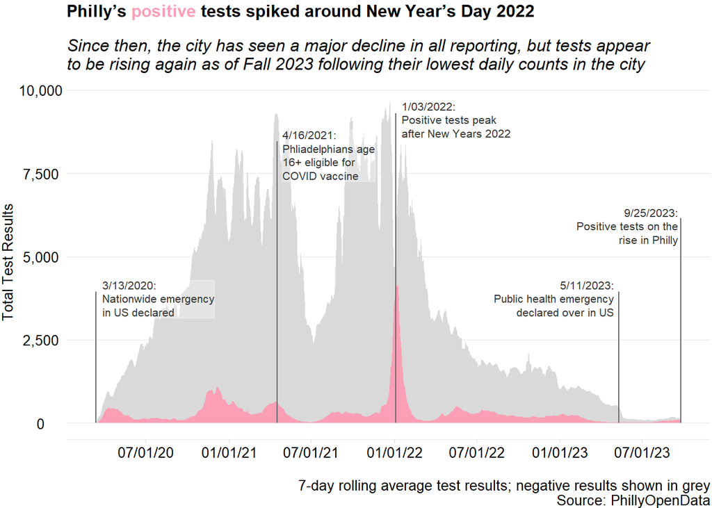

```r
# text for annotations within chart
annotations <- grobTree(
  richtext_grob(
  "<span style='background-color:white'>3/13/2020:<br>Nationwide emergency<br>in US declared</span>",
  x=.055,  y=.395, hjust=0, gp=gpar(col = "grey20", fontsize=8), box_gp = gpar(col = "white", fill = "white", alpha = .3)),
  richtext_grob(
  "<span style='background-color:white'>4/16/2021:<br>Phliadelphians age<br>16+ eligible for<br>COVID vaccine</span>",
  x=.335,  y=.80, hjust=0, gp=gpar(col = "grey20", fontsize=8), box_gp = gpar(col = "white", fill = "white", alpha = .3)),
  richtext_grob(
  "<span style='background-color:white'>1/03/2022:<br>Positive tests peak<br>after New Years 2022</span>",
  x=.52,  y=.90, hjust=0, gp=gpar(col = "grey20", fontsize=8), box_gp = gpar(col = "white", fill = "white", alpha = .3)),
  richtext_grob(
  "<span style='background-color:white'>5/11/2023:<br>Public health emergency<br>declared over in US</span>",
  x=.85,  y=.395, hjust=1, gp=gpar(col = "grey20", fontsize=8), box_gp = gpar(col = "white", fill = "white", alpha = .3)),
   richtext_grob(
  "<span style='background-color:white'>9/25/2023:<br>Positive tests on the<br>rise in Philly</span>",
  x=.95,  y=.6, hjust=1, gp=gpar(col = "grey20", fontsize=8), box_gp = gpar(col = "white", fill = "white", alpha = .3))
  )

ggplot() +
  geom_area(data = covid, aes(x=collection_date, y=rollingAvg_neg), color=NA, fill = "grey85")+
  geom_area(data = covid, aes(x=collection_date, y=rollingAvg_pos), color=NA, fill = "#fa9fb5")+
  geom_segment(data = covid,
               x = ymd("2020-03-13"),
               y = 0,
               xend = ymd("2020-03-13"),
               yend = 3950,
               color = "grey40",
               alpha = .3)+
  geom_segment(data = covid,
               x = ymd("2021-04-16"),
               y = 0,
               xend = ymd("2021-04-16"),
               yend = 8450,
               color = "grey40",
               alpha = .3)+
  geom_segment(data = covid,
               x = ymd("2022-01-03"),
               y = 0,
               xend = ymd("2022-01-03"),
               yend = 9300,
               color = "grey40",
               alpha = .3)+
  geom_segment(data = covid,
               x = ymd("2023-05-11"),
               y = 0,
               xend = ymd("2023-05-11"),
               yend = 3950,
               color = "grey40",
               alpha = .3)+
  geom_segment(data = covid,
               x = ymd("2023-09-25"),
               y = 0,
               xend = ymd("2023-09-25"),
               yend = 6150,
               color = "grey40",
               alpha = .3)+
  labs(title = "Philly's <span style='color:#fa9fb5;'>positive</span> tests spiked around New Year's Day 2022",
       subtitle = "Since then, the city has seen a major decline in all reporting, but tests appear\nto be rising again as of Fall 2023 following their lowest daily counts in the city",
       color = "Test Result",
       x = "", y = "Total Test Results",
       caption = "7-day rolling average test results; negative results shown in grey\nSource: PhillyOpenData") +
  scale_y_continuous(label=comma) +
  theme_musa() +
  theme(panel.grid.major.y = element_line(color="grey90", size = .1),
        axis.line.x = element_line(color = "grey90", size = .1),
        plot.title = element_markdown(size = 12)) +
  scale_x_date(date_labels = "%D",date_breaks = "6 months") +
  annotation_custom(annotations)
```

Our limited knowledge of test results this year due to a lack of reporting makes it more difficult for us to measure COVID-positive case levels in the city and impacts to residents’ health and the economy. While CDC isolation guidelines have changed over the course of the pandemic, each unique positive case of COVID hypothetically leads to at least five days of self-isolating under current guidelines. This can affect residents’ work, education, and leisure time as they are forced to stay indoors or else risk spreading the virus. The time off is especially disruptive for essential workers, such as those working in hospitals or airports.

At-home rapid COVID tests became more widely available in 2022, so these daily test results throughout 2023 may also reflect more severe cases that involve hospitalizations. These hospitalizations can also put other at-risk demographics in the hospital in danger of catching COVID and compounding their initial reasons for being there.

*Vaccine data remains lacking*

Our public data shows that most of the city has at least one dose of the COVID vaccine. However, this data set has not been updated on OpenDataPhilly since 2021. Since these vaccination rates reflect the first dose only, any decrease per Census tract is unlikely. However, we do not have a clear sense of the community’s current vaccination levels and how we compare to the nationally reported number of 7% of adults with the latest booster. We could conduct better targeted outreach to at-risk populations if we had better data reporting.

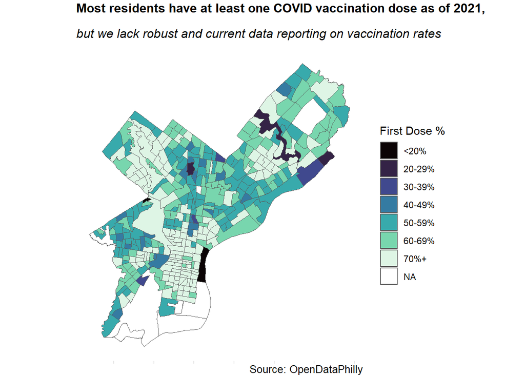

```r
ggplot()+
  geom_sf(data=map_data, aes(fill = dose1_perc))+
  scale_fill_viridis(option = "mako", discrete=TRUE)+
  labs(title = "Most residents have at least one COVID vaccination dose as of 2021,",
       subtitle = "but we lack robust and current data reporting on vaccination rates",
       caption = "Source: OpenDataPhilly",
       fill = "First Dose %")+
  theme_musa() +
  theme(axis.text.x = element_blank(),
        axis.text.y = element_blank(),
        plot.title = element_markdown(size = 12))
```

Additionally, areas of Philadelphia with lower first dose vaccination rates are more noticeable in North Philly and West Philly. Given that many Census tracts in these areas are majority non-white and/or lower income, our communications strategy to reach a wide range of residents in different socioeconomic and demographic contexts is even more important.

*Publicly reported COVID test results have plummeted in 2023*

To reinforce the data decrease we now face, the following chart provides total daily test results officially tracked by Philadelphia. Testing availability was generally more limited in 2020, followed by better testing infrastructure in 2021 that coincided with the highly contagious Omicron variant. 2022 then saw the rise of at-home testing, but the total number of daily positive tests was similar to 2021.

Only in 2023 have we seen a precipitous decline in data tracked by the City. Daily test results collected by Philadelphia decreased to near 0 around Summer 2023, based on the previous timeline chart, and this drop-off is reflected in our total test collection results. However, the relative proportion of positive daily results is still high. These 2023 positive results may again reflect more serious cases that result in hospitalizations, straining our health institutions and people’s lives.

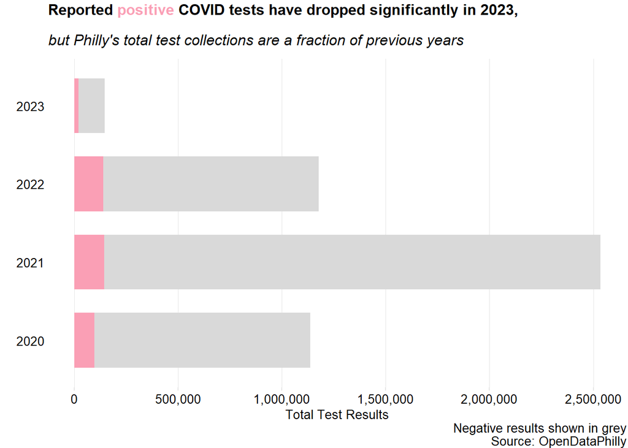

```r
ggplot(data = drop_na(covid_years), aes(fill=test_result, y=total, x=as.character(year))) +
  geom_bar(position="stack", stat="identity", width = .7)+
  scale_fill_manual(values = c("grey85","#fa9fb5")) +
  labs(title = "Reported <span style='color:#fa9fb5;'>positive</span> COVID tests have dropped significantly in 2023,",
       subtitle = "but Philly's total test collections are a fraction of previous years",
       fill = "Test Result",
       x = "", y = "Total Test Results",
       caption = "Negative results shown in grey\nSource: OpenDataPhilly") +
  coord_flip() +
  scale_y_continuous(label=comma) +
  theme_musa()+
  theme(plot.title = element_markdown(size = 12),
        panel.grid.major.x = element_line(color="grey90", size = .1)) +
  theme(legend.position = "none")
```

*Winters in Philadelphia have historically been the worst periods for COVID*

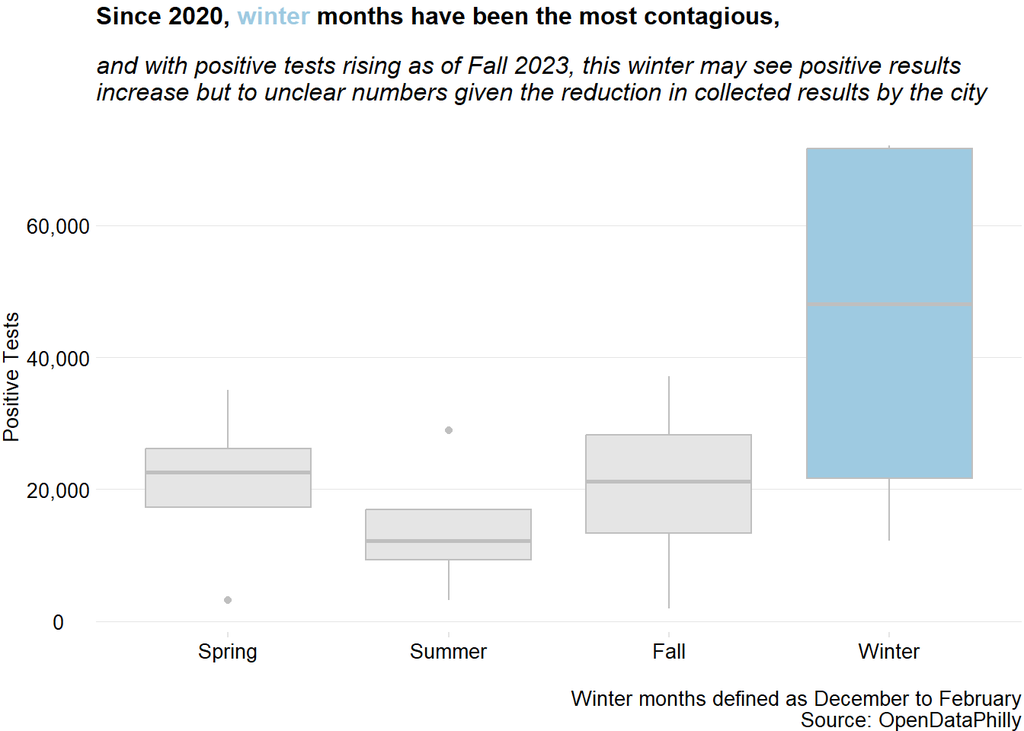

```r
#sets order to keep it chronological
level_order <- c("Spring", "Summer", "Fall", "Winter")

ggplot(na.omit(covid_pos_seasons), aes(x = factor(season, level = level_order), y = total, fill = type)) +
  geom_boxplot(color = "grey75") +
  labs(title = "Since 2020, <span style='color:#9ecae1;'>winter</span> months have been the most contagious,",
       subtitle = "and with positive tests rising as of Fall 2023, this winter may see positive results\nincrease but to unclear numbers given the reduction in collected results by the city",
       x = "", y = "Positive Tests",
       caption = "Winter months defined as December to February\nSource: OpenDataPhilly") +
  scale_fill_manual(values=c("#9ecae1", "grey90"), guide = "none")+
  scale_y_continuous(label=comma) +
  theme_musa() +
  theme(plot.title = element_markdown(size = 12),
        panel.grid.major.y = element_line(color="grey90", size = .1),
        legend.position = "none")
```

Positive test results have already begun to tick up this Fall, which could be a sign of things to come as we head into the holidays. As residents travel and/or celebrate the holidays, demographics most at risk of hospitalization in the community may not realize the actual level of risk they face from COVID now that our data collection is down and precautions like masking or getting vaccinated are no longer widely followed. Our messaging is therefore critical to remind people of best practices as we think about new ways to gather better data long-term.

**Recommendations**  
In the **short-term**, we need to increase our **public messaging** to Philadelphians around **testing, masking, and most importantly, vaccinating against COVID**. We should update our website to make these COVID recommendations more obvious, increase the number of vaccine clinics hosted by the City, and find ways to increase outreach for these simple steps to protect our residents from COVID. We should first review our previous campaigns to see what resonated with different audiences and find ways to implement the most effective wording in our communications. This outreach could include partnering with local non-profits, broadcast messaging through local TV commercials and radio, and/or partnering with institutions like the Philadelphia Eagles to promote vaccination. Additionally, we should clarify guidelines on what Philly residents should do to protect themselves and others when they are exposed or test positive for COVID.

In the **long-term**, we should consider ways to **increase data collection and reporting**. The existing dashboard on our website has limited functionality with only a few metrics tracked, and many of our published data sets are out of date. Daily test collection results is one of our few data sets that continues to be updated, but as we saw in this analysis, the results have become less reliable over time due to at-home testing. Instituting some form of self-reporting on our website and providing better tracking of positive COVID cases and vaccination rates can help us avoid a future crisis and better tailor our messaging to specific populations in the city. Additionally, the lessons we learn from implementing better data management practices now can lay the groundwork for more effective reporting in the future, should we face another pandemic-level health crisis.